# Machine Learning for Human Activity Recognition

## Summary

This project builds a machine learning model to classify human activity, as measured by accelerometers, into one of 5 categories. The accuracy of the model is evaluated for out of sample errors, and predictions are made on a final set of size 20.

## Data

The dataset consists of accelerometer data from the belt, forearm, arm, and dumbell of 6 participants. These participants were asked to perform barbell lifts in 5 different ways. Further details are available [here](http://groupware.les.inf.puc-rio.br/har). The data is loaded into R as follows:

```r
if (!file.exists("data/")) { dir.create("./data/") }
if (!file.exists("data/pml-training.csv")) { download.file("https://d396qusza40orc.cloudfront.net/predmachlearn/pml-training.csv","data/pml-training.csv",method="curl") }
if (!file.exists("data/pml-testing.csv"))  { download.file("https://d396qusza40orc.cloudfront.net/predmachlearn/pml-testing.csv", "data/pml-testing.csv", method="curl") }
df.train <- read.csv("data/pml-training.csv", na.strings=c("","NA"))
df.test  <- read.csv("data/pml-testing.csv",  na.strings=c("","NA"))
```

### Cleaning the dataset

First, functions are introduced for counting columns with NAs, cleaning column names, and removing columns unnecessary for building the prediction model.

```r
col.count.NAs <- function(df) {
  apply(df, 2, function(x) sum(is.na(x)))
}

clean.dataset <- function(df) {
  col.names <- names(df)
  names(df) <- gsub("_", ".", col.names)
  df <- subset(df,select=-cvtd.timestamp)
  df <- subset(df,select=-raw.timestamp.part.1)
  df <- subset(df,select=-raw.timestamp.part.2)
  df <- subset(df,select=-new.window)
  df <- subset(df,select=-num.window)
  df <- subset(df,select=-X)
  df <- subset(df,select=-user.name)
  df
}
```

Next, with these functions, the data frames, `df.train` and `df.test`, are processed as follows:

```r
col.NA.percentages <- col.count.NAs(df.train)/dim(df.train[1])
df.train <- subset(df.train,select=col.NA.percentages < 0.9)
df.test  <- subset(df.test, select=col.NA.percentages < 0.9)
df.train <- clean.dataset(df.train)
df.test  <- clean.dataset(df.test)
```

Here, we have decided that columns with more than 90% NAs are unlikely to be able to improve the accuracy of the models.

### Splitting the dataset into training and testing sets

As the data set is huge, processing takes a considerable amount of time. Little difference in accuracy is observed when if the model is trained on 20% of the data (versus 30%). Hence, only 20% of the data is used for the training set. The remaining data can be used for testing / validation, or estimating out of sample errors.

```r
suppressPackageStartupMessages(library(caret))
set.seed(314159)
folds <- createFolds(y=df.train$classe, k=5, list=TRUE)
fold1 <- folds[[1]]
fold2 <- folds[[2]]
fold3 <- folds[[3]]
fold4 <- folds[[4]]
fold5 <- folds[[5]]
training1 <- df.train[fold1,]
testing1  <- df.train[fold4,]
validatn1 <- df.train[fold5,]
```

## The Machine Learning Model

Multicore processing is enabled using the `doParallel` library:

```r
suppressPackageStartupMessages(library(doParallel))
ncpus <- detectCores()
cl <- makeCluster(ifelse(ncpus > 4, 4, ncpus))
registerDoParallel(cl)
```

The machine learning models are built using the `train()` function, with the `trainControl()` set to use 5-fold cross validation. A list of available methods was checked using `names(getModelInfo())`, whereby methods ‘rf’, ‘gbm’, and ‘C5.0’ were found to give good accuracy.

```r
tc <- trainControl(method="cv", number=5) #5-fold cross-validation
set.seed(314159)
rfModel1s <- train(classe ~ ., data=training1, method="rf", prox=TRUE, trControl=tc, preProc = c("center", "scale"))
gbmModel1 <- train(classe ~ ., data=training1, method="gbm", trControl=tc)
C50Model1 <- train(classe ~ ., data=training1, method="C5.0", trControl=tc)
```

### Estimates on out-of-sample accuracy

To get an estimate on the out-of-sample accuracy, the following functions were used:

```r
get.prediction.1 <- function(my.model, my.test.data) {
  my.pred <- predict(my.model,newdata=my.test.data)
  tbl <- table(my.pred,my.test.data$classe)
  acc <- sum(diag(tbl)) / sum(rowSums(tbl))
  acc
}

get.prediction <- function(my.model) {
  c(get.prediction.1(my.model, df.train[fold2,]),
    get.prediction.1(my.model, df.train[fold3,]),
    get.prediction.1(my.model, df.train[fold4,]),
    get.prediction.1(my.model, df.train[fold5,]))
}
```

Apparently, the out-of-sample accuracies (note: `out-of-sample error = 1 - out-of-sample accuracy` assumed) are good in all 3 cases:

```r
(rf.acc  <- get.prediction(rfModel1s))
```

```
## [1] 0.9778344 0.9796126 0.9734964 0.9765605
```

```r
(gbm.acc <- get.prediction(gbmModel1))
```

```
## [1] 0.9633121 0.9561672 0.9464832 0.9513376
```

```r
(C50.acc <- get.prediction(C50Model1))
```

```
## [1] 0.9765605 0.9813965 0.9732416 0.9737580
```

```r
1-apply(data.frame(rf=rf.acc,gbm=gbm.acc,C50=C50.acc),2,max)
```

```
##         rf        gbm        C50
## 0.02038736 0.03668790 0.01860347
```

### Receiver Operating Characteristic (ROC) Curve

For the ROC curve, we choose the random forest model for our plot, using the following code:

```r
library(pROC)
rf1Probs <- predict(rfModel1s, testing1, type = "prob")
rf1ROCa <- roc(testing1$classe, rf1Probs[, "A"])
rf1ROCb <- roc(testing1$classe, rf1Probs[, "B"])
rf1ROCc <- roc(testing1$classe, rf1Probs[, "C"])
rf1ROCd <- roc(testing1$classe, rf1Probs[, "D"])
rf1ROCe <- roc(testing1$classe, rf1Probs[, "E"])
plot( rf1ROCa, type = "S", col='red', bty='n',
      main="Receiver Operating Characteristic (ROC) Curves")
```

```
##
## Call:
## roc.default(response = testing1$classe, predictor = rf1Probs[,     "A"])
##
## Data: rf1Probs[, "A"] in 1116 controls (testing1$classe A) > 759 cases (testing1$classe B).
## Area under the curve: 0.9985
```

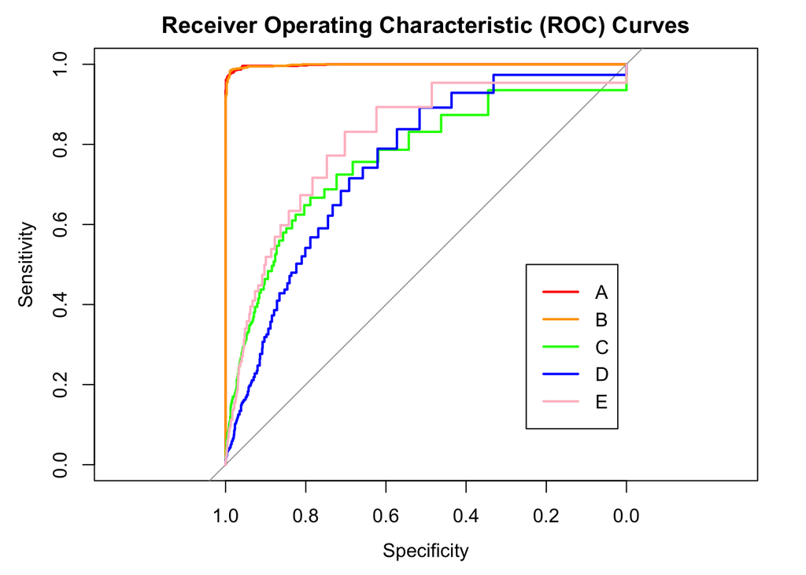

```r
lines(rf1ROCb, type = "S", col='orange')
lines(rf1ROCc, type = "S", col='green')
lines(rf1ROCd, type = "S", col='blue')
lines(rf1ROCe, type = "S", col='pink')
legend(0.25, 0.5, c("A","B","C","D","E"), lty=rep(1,5), lwd=rep(2,5),
       col=c("red","orange","green","blue","pink"))
```

The random forest model details are as follows:

```r
rfModel1s
```

```
## Random Forest
##
## 3924 samples
##   52 predictor
##    5 classes: 'A', 'B', 'C', 'D', 'E'
##
## Pre-processing: centered, scaled
## Resampling: Cross-Validated (5 fold)
##
## Summary of sample sizes: 3139, 3137, 3139, 3140, 3141
##
## Resampling results across tuning parameters:
##
##   mtry  Accuracy   Kappa      Accuracy SD  Kappa SD
##    2    0.9630465  0.9532188  0.009792046  0.012395058
##   27    0.9686565  0.9603357  0.003170968  0.004019513
##   52    0.9617742  0.9516280  0.006913121  0.008766573
##
## Accuracy was used to select the optimal model using  the largest value.
## The final value used for the model was mtry = 27.
```

### Combining models

Lastly, a check is made to see if a combined model would further improve accuracy.

```r
predict3 <- function(model1,model2,model3,my.test.data) {
  pred1 <- predict(model1,newdata=my.test.data)
  pred2 <- predict(model2,newdata=my.test.data)
  pred3 <- predict(model3,newdata=my.test.data)
  data.frame(pred1,pred2,pred3)
}
combine3 <- function(model1,model2,model3,my.test.data) {
  predDF <- predict3(model1,model2,model3,my.test.data)
  predDF$classe <- my.test.data$classe
  combinedModel <- train(classe ~ ., method="rf", data=predDF)
  combinedModel
}
combinedModel <- combine3(rfModel1s,gbmModel1,C50Model1,df.train[fold2,])
predVDF <- predict3(rfModel1s,gbmModel1,C50Model1,validatn1)
combPredV <- predict(combinedModel,newdata=predVDF)
stopCluster(cl)
```

Apparently, the accuracy does not substantially improve:

```r
(tbl <- table(combPredV,validatn1$classe))
```

```
##
## combPredV    A    B    C    D    E
##         A 1105    5    0    1    0
##         B    5  738    8    0    3
##         C    4   15  660   12    0
##         D    0    1   11  628    6
##         E    2    0    5    3  713
```

```r
(combined.accuracy <- sum(diag(tbl)) / sum(rowSums(tbl)))
```

```
## [1] 0.9793631
```

## Predictions on `df.test`

Finally, we test each of the models on the 20 observations in `df.test`

```r
answers1 = predict(rfModel1s,newdata=df.test)
answers2 = predict(gbmModel1,newdata=df.test)
answers3 = predict(C50Model1,newdata=df.test)
predVDF <- predict3(rfModel1s,gbmModel1,C50Model1,df.test)
answers4 <- predict(combinedModel,newdata=predVDF)
```

Apparently, the answers are mostly identical:

```r
rbind(answers1,answers2,answers3,answers4)
```

```
##          [,1] [,2] [,3] [,4] [,5] [,6] [,7] [,8] [,9] [,10] [,11] [,12]
## answers1    2    1    2    1    1    5    4    4    1     1     2     3
## answers2    2    1    2    1    1    5    4    2    1     1     2     3
## answers3    2    1    2    1    1    5    4    2    1     1     2     3
## answers4    2    1    2    1    1    5    4    2    1     1     2     3
##          [,13] [,14] [,15] [,16] [,17] [,18] [,19] [,20]
## answers1     2     1     5     5     1     2     2     2
## answers2     2     1     5     5     1     2     2     2
## answers3     2     1     5     5     1     2     2     2
## answers4     2     1     5     5     1     2     2     2
```

The final row, coming from the combined model, is chosen as the final answer for submission:

```r
(answers <- answers4)
```

```
##  [1] B A B A A E D B A A B C B A E E A B B B
## Levels: A B C D E
```

## Summary

- machine learning models are built from 20% of the data available
- methods: rf (random forest), gbm, and C5.0 are found to have minimum accuracies of 0.9734964, 0.9464832, and 0.9732416, respectively.
- the combined model did not substantially improve accuracy; accuracy for the combined case was 0.9793631.